# Variography using (mini)gstlearn - Correction

Emilie Chautru, Mike Pereira, and Thomas Romary

Option Géostatistique 2024

```r
knitr::opts_chunk$set(echo = TRUE)
rm(list=ls())
library(minigst)
```

# Preamble

## Loading the Meuse dataset

```r
library(sp) # load library
data(meuse) # load data
```

Comments on the dataset (from https://www.rdocumentation.org/packages/sp/versions/1.3-1/topics/meuse):

- **x** and **y**: easting and northing (m) coordinates
- **cadmium**, **copper**, **lead**, **zinc**: topsoil heavy metal concentrations (ppm) (NB: obtained from composite samples **15m x 15m**)
- **elev**: relative elevation above the river (m)
- **dist**: distance to the river (normalized between 0 and 1)
- **om**, **soil**, **lime**: soil characteristics (content of organic matter, type of soil, presence of lime)
- **ffreq**: flooding frequency
- **landuse**: landuse classes
- **dist.m**: distance to the river (m)

## Visualizing heavy metal concentrations

```r
OptCst_defineByKey("ASP",0) # Fix the aspect ratio in all future plots
```

1. Create a gstlearn `database` called `data` from the `meuse` dataset. Don’t forget to set the correct variables (`x` and `y`) as coordinates! Also, add the log concentrations of `cadmium`, `copper`, `lead` and `zinc` to the resulting `database`, under the names `log_cadmium`, `log_copper`, `log_lead` and `log_zinc`. *(Hint: Use the functions `dfToDb` and `addVarToDb`)*

```r
## Create Db from dataframe
data = dfToDb(meuse,coordnames = c("x","y"))

## Add log concentrations
var_name = c( "cadmium", "copper", "lead", "zinc")
addVarToDb(data,var=log(meuse[,var_name]),vname = paste0("log_",var_name))
```

2. Plot each heavy metal (log)concentration. *(Hint: Use the function `db_plot_point`)*

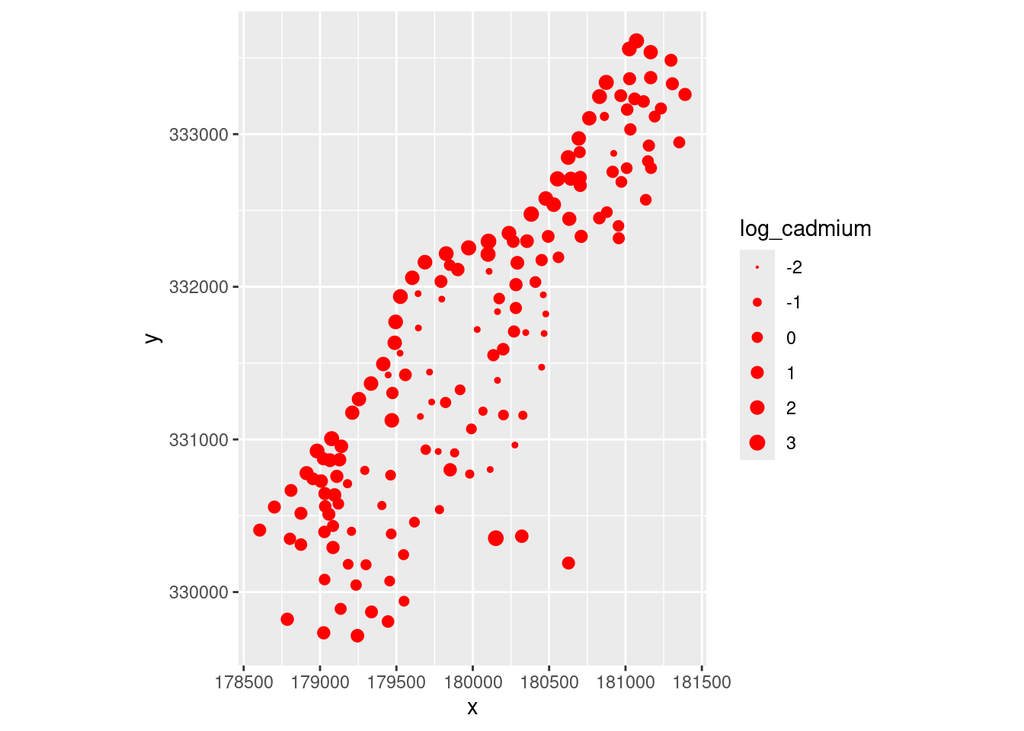

```r
dbplot_point(data,size="log_cadmium",sizeRange = c(0.1,3), pointColor = "red",
             xlab = "Easting (m)", ylab = "Northing (m)", title = "Cadmium")
```

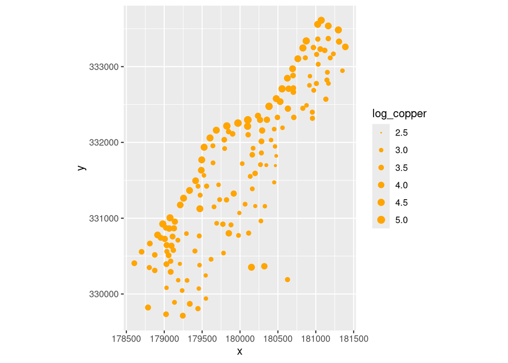

```r
dbplot_point(data,size="log_copper",sizeRange = c(0.1,3), pointColor = "orange",
             xlab = "Easting (m)", ylab = "Northing (m)", title = "Copper")
```

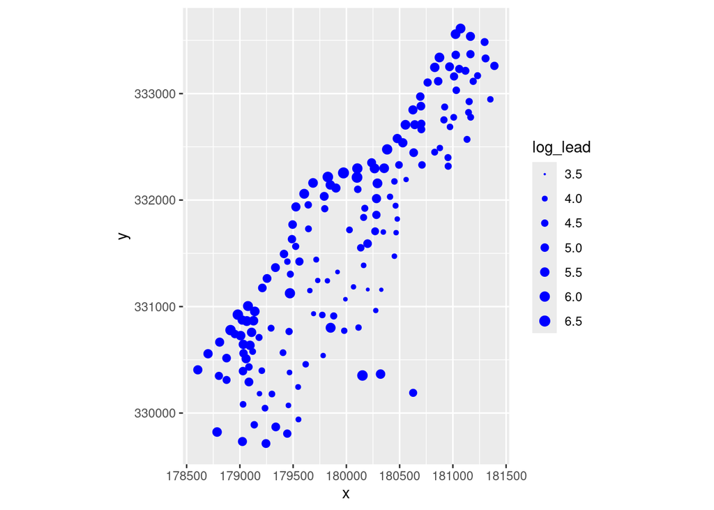

```r
dbplot_point(data,size="log_lead",sizeRange = c(0.1,3), pointColor = "blue",
             xlab = "Easting (m)", ylab = "Northing (m)", title = "Lead")
```

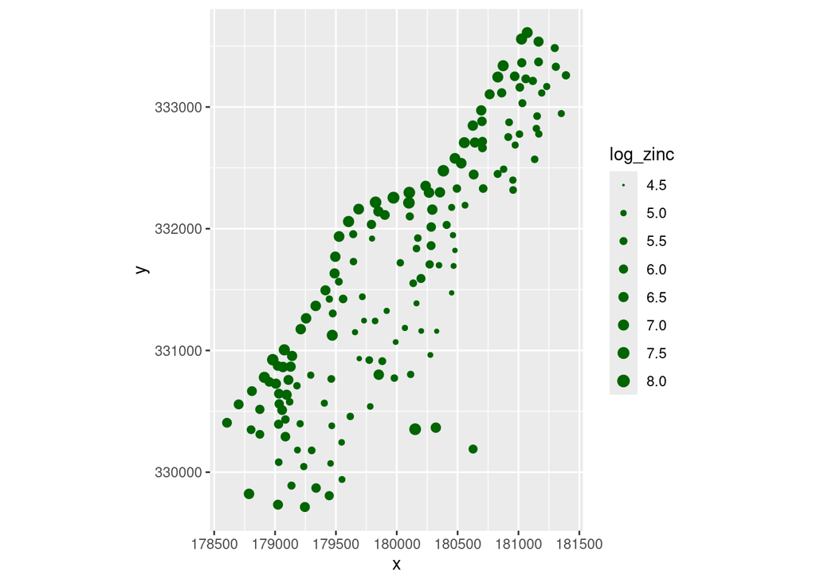

```r
dbplot_point(data,size="log_zinc",sizeRange = c(0.1,3), pointColor = "darkgreen",
             xlab = "Easting (m)", ylab = "Northing (m)", title = "Zinc")
```

3. Compute basic statistics of each heavy metal (log)concentration. *(Hint: Use the function `summaryStats`)*

```r
# Statistics on the variables
print(summaryStats(data,vname = c("cadmium","copper","lead","zinc")))
```

```
##         NUM   MIN    MAX       MEAN       STDV   MED
## cadmium 155   0.2   18.1   3.245806   3.523746   2.1
## copper  155  14.0  128.0  40.316129  23.680436  31.0
## lead    155  37.0  654.0 153.361290 111.320054 123.0
## zinc    155 113.0 1839.0 469.716129 367.073788 326.0
```

```r
# Statistics on the log-variables
print(summaryStats(data,vname = paste0("log_", c("cadmium","copper","lead","zinc"))))
```

```
##             NUM       MIN      MAX      MEAN      STDV       MED
## log_cadmium 155 -1.609438 2.895912 0.5610659 1.2249490 0.7419373
## log_copper  155  2.639057 4.852030 3.5567508 0.5083385 3.4339872
## log_lead    155  3.610918 6.483107 4.8070527 0.6664501 4.8121844
## log_zinc    155  4.727388 7.516977 5.8857759 0.7218811 5.7868974
```

4. Compare the basic statistics above to those obtained when considering only the points having a Cadmium log-concentration above 0.5. *(Hint: Use the functions `addSel`, and `summaryStats`)*

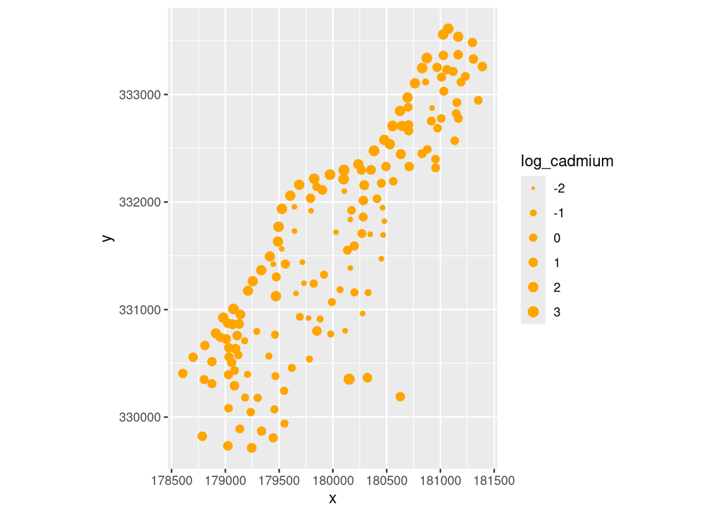

```r
## Select values above a threshold for cadmium
addSel(data,sel=data["log_cadmium"] >= 0.5)

# Plot
plt=dbplot_point(data,size="log_cadmium", pointColor = "orange",
             xlab = "Easting (m)", ylab = "Northing (m)", title = "Cadmium >= 2")
print(plt)
```

```r
# Compute stats
print(summaryStats(data,vname = paste0("log_", c("cadmium","copper","lead","zinc"))))
```

```
##             NUM       MIN      MAX     MEAN      STDV      MED
## log_cadmium  90 0.5306283 2.895912 1.403290 0.6460865 1.163151
## log_copper   90 3.0910425 4.852030 3.854555 0.4548488 3.839394
## log_lead     90 4.1743873 6.483107 5.245113 0.4756994 5.230880
## log_zinc     90 5.1704840 7.516977 6.356024 0.5429424 6.391895
```

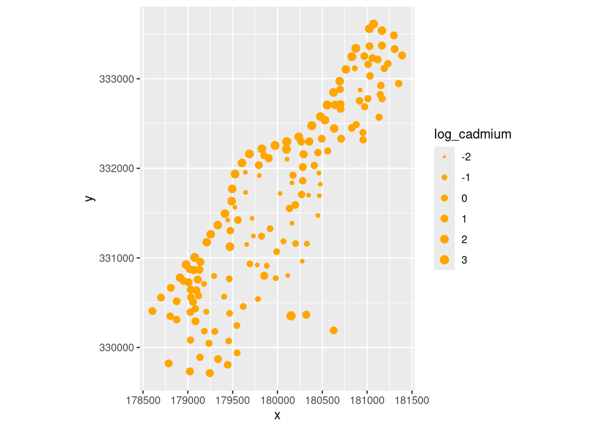

```r
#--------------------------------------------

# Remove the selection
clearSel(data)

# Plot
plt=dbplot_point(data,size="log_cadmium", pointColor = "orange",
             xlab = "Easting (m)", ylab = "Northing (m)", title = "Cadmium")
print(plt)
```

4. Fit the regression line of the coordinates **y** as a function of the coordinates **x**. Compare the basic statistics of each heavy metal concentration above and below the regression line. *(Hint: Use the functions `lm`, `addSel`, and `summaryStats`)*

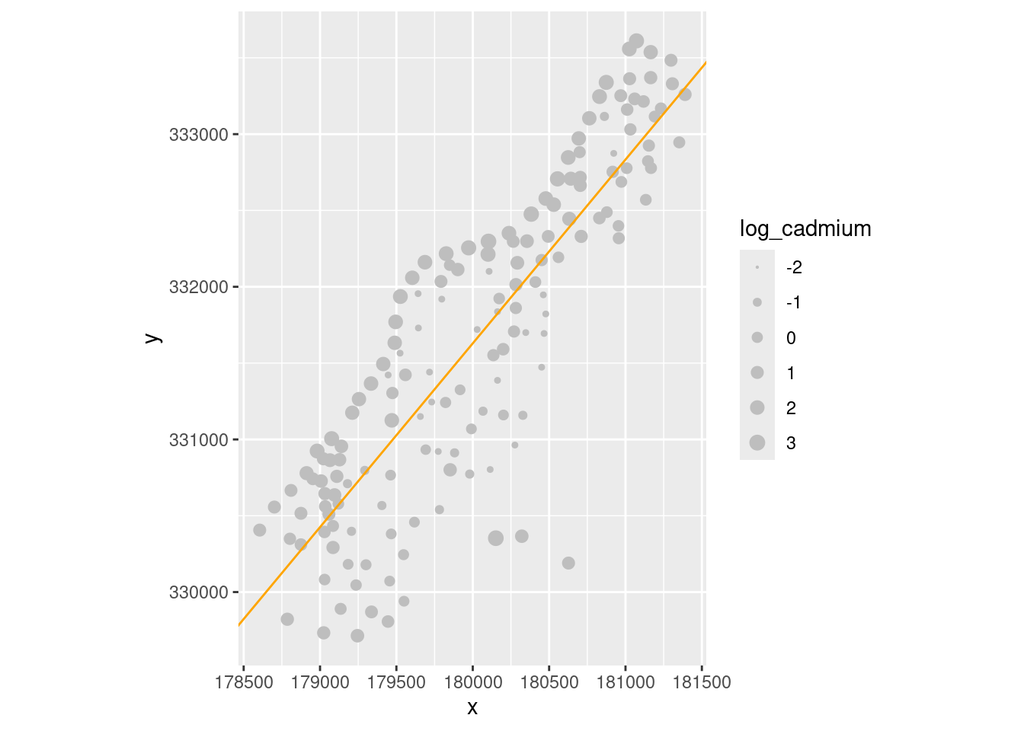

```r
## Fit regression line
reg = lm(data["y"] ~ data["x"])
a = reg$coefficients[2]
b = reg$coefficients[1]

# Plot regression line
plt=dbplot_point(data,size="log_cadmium",sizeRange = c(0.1,3), pointColor = "gray",
             xlab = "Easting (m)", ylab = "Northing (m)", title = "Cadmium")
plt=addLines(plt,a=a,b=b,color = "orange")
print(plt)
```

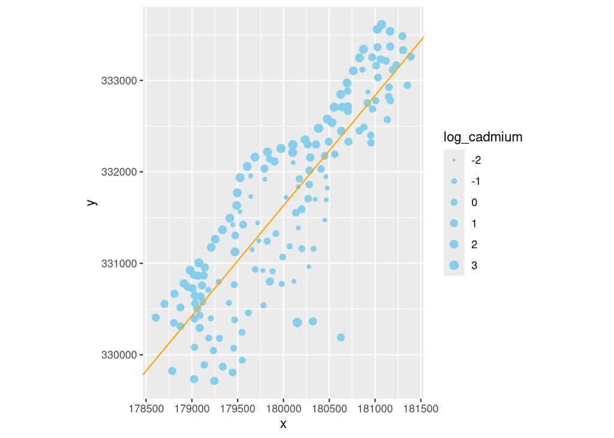

```r
#-----------------------------------------------

## Select values below the regression line
addSel(data,sel=(data["y"] < a * data["x"] +b))

# Plot
plt=dbplot_point(data,size="log_cadmium", pointColor = "skyblue",
             xlab = "Easting (m)", ylab = "Northing (m)", title = "Cadmium ((selection y < a*x +b))")
plt=addLines(plt,a=a,b=b,color = "orange")
print(plt)
```

```r
# Compute stats
print(summaryStats(data,vname = paste0("log_", c("cadmium","copper","lead","zinc"))))
```

```
##             NUM       MIN      MAX        MEAN      STDV       MED
## log_cadmium  65 -1.609438 2.895912 -0.04575219 0.9768063 0.1823216
## log_copper   65  2.639057 4.330733  3.24905029 0.3233211 3.1780538
## log_lead     65  3.610918 6.139885  4.36450237 0.5488525 4.2195077
## log_zinc     65  4.727388 7.421776  5.41974594 0.5475409 5.2933048
```

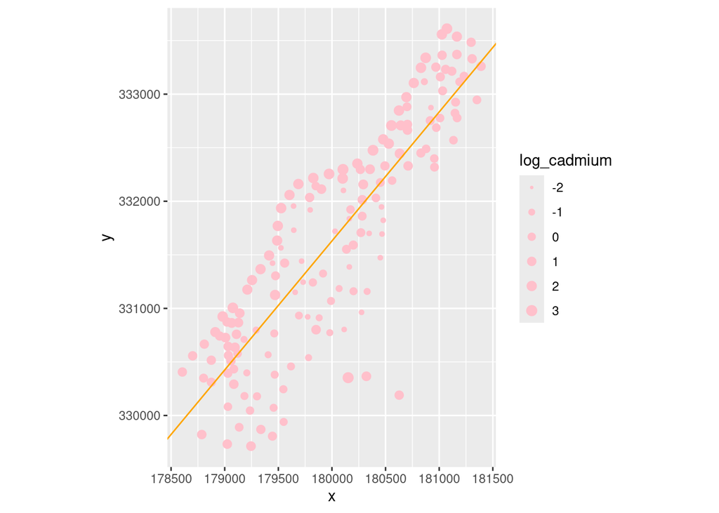

```r
#-----------------------------------------------

## Select values above the regression line
addSel(data,sel=(data["y"] >= a * data["x"] +b))

# Plot
plt=dbplot_point(data,size="log_cadmium", pointColor = "pink",
             xlab = "Easting (m)", ylab = "Northing (m)", title = "Cadmium (selection y >= a*x +b)")
plt=addLines(plt,a=a,b=b,color = "orange")
print(plt)
```

```r
# Compute stats
print(summaryStats(data,vname = paste0("log_", c("cadmium","copper","lead","zinc"))))
```

```
##             NUM       MIN      MAX      MEAN      STDV      MED
## log_cadmium  90 -1.609438 2.833213 0.9993235 1.2029470 1.047165
## log_copper   90  2.995732 4.852030 3.7789790 0.5028641 3.650574
## log_lead     90  4.025352 6.483107 5.1266723 0.5527894 5.132640
## log_zinc     90  4.934474 7.516977 6.2223530 0.6426026 6.312638
```

```r
#-----------------------------------------------

# Remove the selection
clearSel(data)
```

# Variography using R

## Loading the data

Create a database `dat` containing the coordinates and the metal log-concentrations at each point of the `meuse` dataset. Recall that, for convenience, we shall work with the logarithms of the concentrations. *(Hint: You can do this by extracting the appropriate variables from the database `data` using: `data[vector_of_variable_names]`)*

```r
vn_list = c("x", "y", paste0("log_", c("cadmium", "copper", "lead", "zinc")))
dat = data[vn_list]
n=nrow(dat)
```

## Variogram cloud

1. Create a matrix `dist_mat` containing all the distances between the points and a matrix `vario` containing the quantities
   $$\frac{1}{2}(Z(x_i)-Z(x_j))^2$$
   for all the pairs of points $i$ and $j$ (using the function `outer`). You may choose to work with the cadmium concentration for this example. *(Hint: Use the function `outer` or the function `dist`)*

```r
# Matrix containing all the distances between pairs of points
dist_mat = sqrt(outer(dat[,"x"],dat[,"x"],"-")^2+outer(dat[,"y"],dat[,"y"],"-")^2)
##alternative:
# dist_mat = as.matrix(dist(dat[,1:2]))

# Matrix containing the square differences of Z between pairs of points
vario = 1/2*outer(dat[,"log_cadmium"],dat[,"log_cadmium"],"-")^2
## alternative
# vario = 1/2*as.matrix(dist(dat$log_cadmium))^2
```

2. Plot the variogram cloud for the cadmium concentration, and eventually for the other metals. *(Hint: Use the function `plot`)*

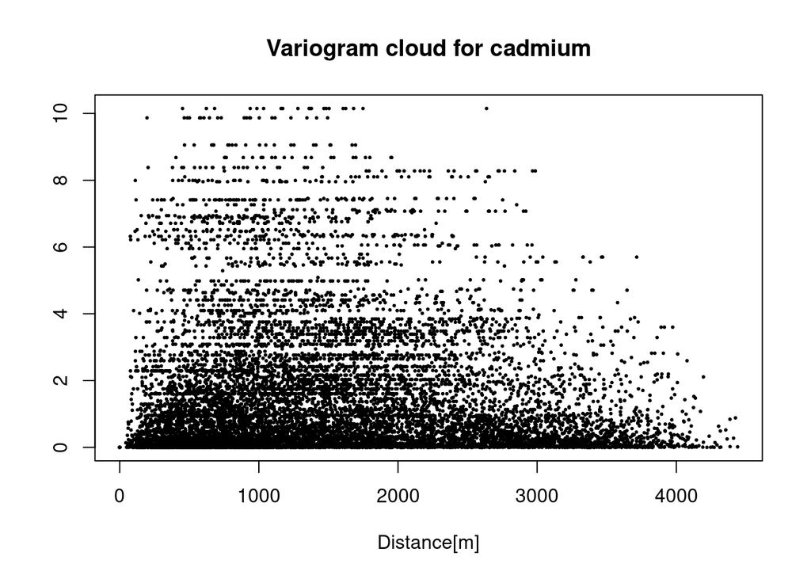

```r
plot(dist_mat,vario,cex=.25,xlab="Distance[m]",ylab=" ",main="Variogram cloud for cadmium",pch=19)
```

## Experimental variogram (omnidirectional)

1. Compute the experimental variogram (`hh`,`gg`) for a set of lags and the number of pairs `npairs` used to compute each value. *(Hint: use either a loop or the functions `cut` and `tapply`. The output of the function `cut` is a factor (`R` object), you may use the function `table` to compute the number of pairs for each value.)*

```r
lags = seq(0,2000,by=100)

# With the functions cut and tapply
sets = cut(dist_mat,lags) # assign a lag to each distance
hh = tapply(dist_mat,sets,mean) # mean distance for each set
gg = tapply(vario,sets,mean) # mean "variogram" value for each set
npairs = table(sets) # number of pairs for each set

# With a loop
lags = seq(0,2000,by=100)
hh = rep(0,length(lags))
gg = rep(0,length(lags))
npairs = rep(0,length(lags))
for (i in seq(lags)){
  sel = dist_mat<=lags[i+1] & dist_mat>lags[i]
  hh[i] = mean(dist_mat[sel])  # average distance of the selected pairs for each lag
  gg[i] = mean(vario[sel])  # average vario of the selected pairs for each lag
  npairs[i] = length(which(sel)) # number of selected pairs
}
gg = gg[1:20]
hh = hh[1:20]
npairs = npairs[1:20]
```

2. Plot the experimental variogram for the cadmium concentration and display the number of pairs used to compute each point of the variogram. *(Hint: Use the functions `plot` and `text`)*

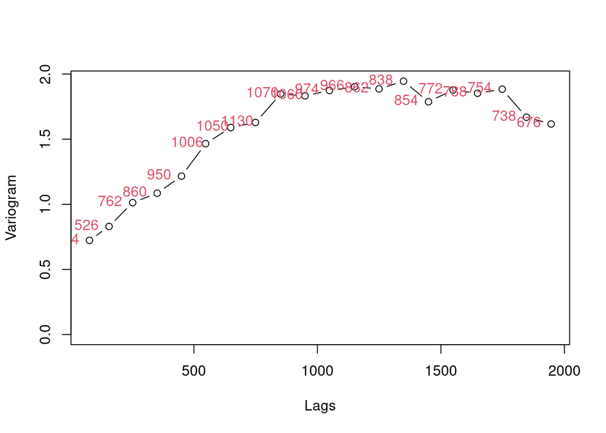

```r
plot(hh,gg,type="b",ylim = c(0,max(gg)),xlab="Lags",ylab="Variogram")
text(hh,gg,npairs,pos=4,offset=-2,col=2)
```

## Variogram fitting

In this section, we fit a variogram model on the experimental variogram computed previously.

1. Create a function `expo` returning the evaluation of an exponential variogram model with range `a` and sill `C` at a lag value `h`.

```r
expo = function(x,a,C){
  C*(1-exp(-x/a))
}
```

2. Manual fitting : try a few values of `(a,C)` to get a first guess on the couple that best fits the experimental variogram.

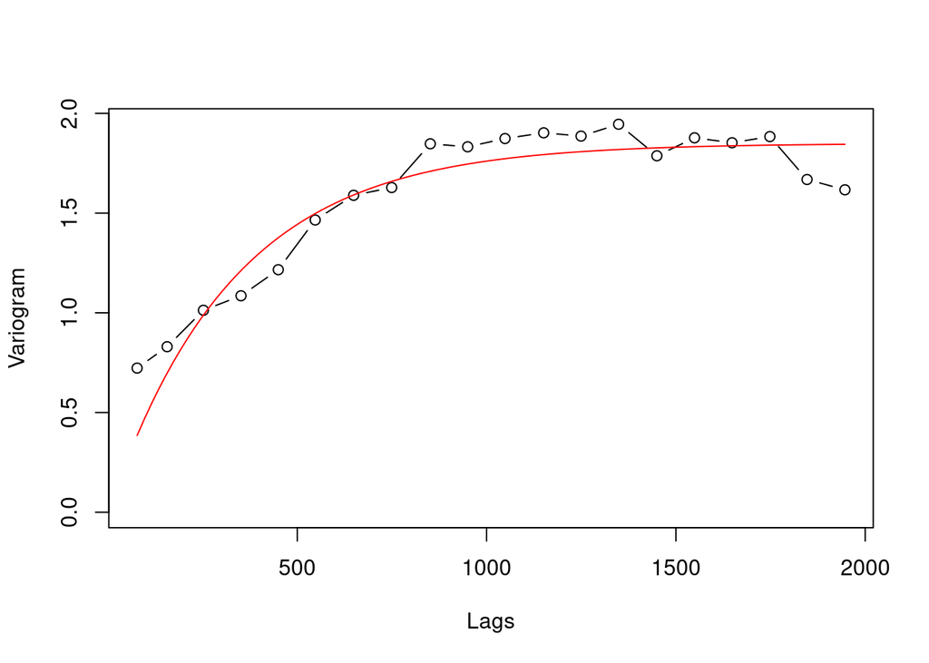

```r
a = 330
C = 1.85

plot(hh,gg,type="b",ylim=c(0,max(gg)),xlab="Lags",ylab="Variogram")
curve(expo(x,a,C),add=TRUE,col="red")
```

```r
# or, equally,
# lines(hh,expo(hh,a,C),add=T,col=2)
```

3. Automatic fitting : ¨
- Option 1: use the functions `nls` and `predict` to build a nonlinear least squares estimates and optimize it. Plot the optimized model on top of the experimental variogram.
- Option 2: use the function `optim` to find those parameters. In that case, you need to build a function that takes a vector `theta=c(a,C)` as input and returns the sum of squares you want to minimize. You can compare both methods.

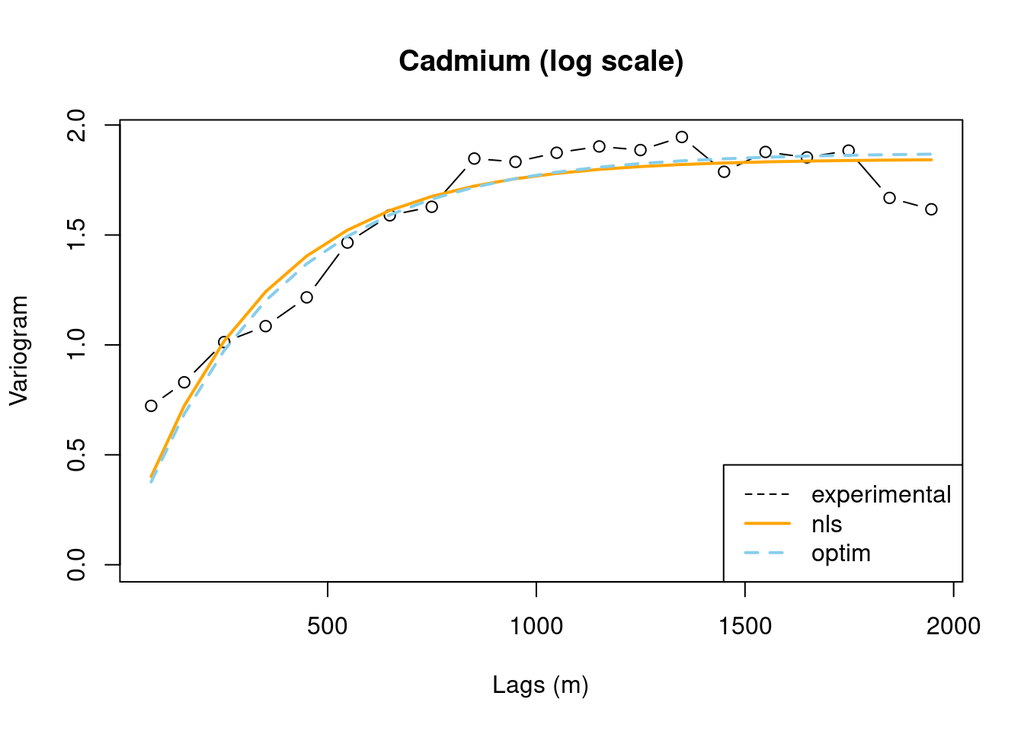

```r
hh2 = hh
gg2 = gg
# option 1
m = nls(gg2~expo(hh2,a,C),start=c(a=400,C=2))

# option 2
fun_optim <- function(theta){
  sum(npairs*(gg-expo(hh,theta[1],theta[2]))^2)
}
res_optim = optim(c(400,2),fun_optim)
theta_optim = res_optim$par # optimized parameters

# comparing the result
plot(hh2, gg2, type="b", ylim = c(0,max(gg2)), xlab="Lags (m)",ylab="Variogram", main ="Cadmium (log scale)")

# automatic fitting using non linear least squares
lines(hh2, predict(m,list(hh2)), col = "orange", lw = 2)
# automatic fitting minimizing the mean squared error
lines(hh2, expo(hh2, a = theta_optim[1], C = theta_optim[2]), col = "skyblue", lty = 2, lw = 2)

# or
# curve(predict(m,list(hh2=x)), add = TRUE, col= "orange", lw = 2)
# curve(expo(x,theta_optim[1],theta_optim[2]), add=TRUE, col="skyblue", lty = 2, lw = 2)

legend("bottomright",
       legend = c("experimental", "nls", "optim"),
       lty = c(2, 1, 2),
       col = c("black", "orange", "skyblue"),
       lw = c(1, 2, 2))
```

```r
# display the optimized parameters
m
```

```
## Nonlinear regression model
##   model: gg2 ~ expo(hh2, a, C)
##    data: parent.frame()
##       a       C
## 314.297   1.846
##  residual sum-of-squares: 0.3296
##
## Number of iterations to convergence: 3
## Achieved convergence tolerance: 7.765e-07
```

```r
theta_optim
```

```
## [1] 342.968756   1.873905
```

# Variography using *gstlearn*

## Variogram cloud

For one metal concentration (cadmium for example), compute and plot the variogram cloud (functions `VarioParam_createOmniDirection` and `db_variogram_cloud`). NB: the variogram cloud is computed for the variable located as `"z1"`. In **gstlearn**, variogram clouds are computed as grids.

The data is modelled as *samples of a regionalized* variable $z$, i.e. as evaluations at locations $x_1,..,x_n$ of a variable $z$ defined across a spatial domain:
$$\lbrace z_i = z(x_i) : i = 1, ...,
n\rbrace.$$

The variogram cloud is the set of pair of points defined as
$$\big\lbrace \big( \Vert x_i -
x_j\Vert, \frac{1}{2}\big\vert z(x_i)-z(x_j)\big\vert^2 \big)
\quad\text{where}\quad 1\le i\le j\le n \big\rbrace$$

```r
## Create variogram cloud
grid.cloud = vario_cloud(data,vname = "log_cadmium")
grid.cloud$display()
```

```
##
## Data Base Grid Characteristics
## ==============================
##
## Data Base Summary
## -----------------
## File is organized as a regular grid
## Space dimension              = 2
## Number of Columns            = 4
## Total number of samples      = 10000
##
## Grid characteristics:
## ---------------------
## Origin :      0.000     0.000
## Mesh   :     47.899     0.045
## Number :        100       100
##
## Variables
## ---------
## Column = 0 - Name = rank - Locator = NA
## Column = 1 - Name = x1 - Locator = x1
## Column = 2 - Name = x2 - Locator = x2
## Column = 3 - Name = Cloud.log_cadmium - Locator = NA
```

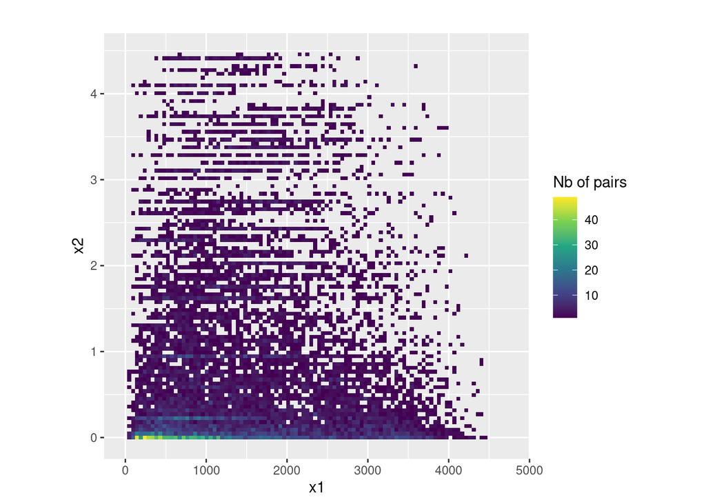

```r
## Plot variogram cloud
dbplot_grid(grid.cloud,color="Cloud.log_cadmium",legendTitle="Nb of pairs")
```

## Experimental variogram (omnidirectional)

For one metal concentration, compute and plot the experimental variogram. Try different values of lag and comment the results.

```r
varioexp=vario_exp(data,vname="log_cadmium",nlag=20, dlag=100, toldis = 0.5)
varioexp
```

```
##
## Variogram characteristics
## =========================
## Number of variable(s)       = 1
## Number of direction(s)      = 1
## Space dimension             = 2
## Variable(s)                 = [log_cadmium]
##
## Variance-Covariance Matrix     1.491
##
## Direction #1
## ------------
## Number of lags              = 20
## Direction coefficients      =      1.000     0.000
## Direction angles (degrees)  =      0.000
## Tolerance on direction      =     90.000 (degrees)
## Calculation lag             =    100.000
## Tolerance on distance       =     50.000 (Percent of the lag value)
##
## For variable 1
##       Rank    Npairs  Distance     Value
##          0     2.000    46.588     0.068
##          1   164.000   114.628     0.739
##          2   328.000   203.112     0.946
##          3   398.000   299.574     0.985
##          4   474.000   400.659     1.150
##          5   508.000   500.738     1.464
##          6   499.000   601.022     1.485
##          7   545.000   701.796     1.602
##          8   526.000   798.511     1.739
##          9   554.000   898.781     1.786
##         10   522.000  1001.477     1.952
##         11   460.000  1100.095     1.816
##         12   469.000  1198.175     1.909
##         13   428.000  1300.676     1.864
##         14   410.000  1400.105     1.946
##         15   400.000  1495.993     1.860
##         16   414.000  1598.709     1.810
##         17   381.000  1700.304     1.821
##         18   387.000  1800.976     1.870
##         19   350.000  1901.279     1.507
```

We now plot the experimental variogram. In the resulting figure, the experimental variogram is plotted in blue, and the dashed blacked line corresponds to the value of the variance of the data.

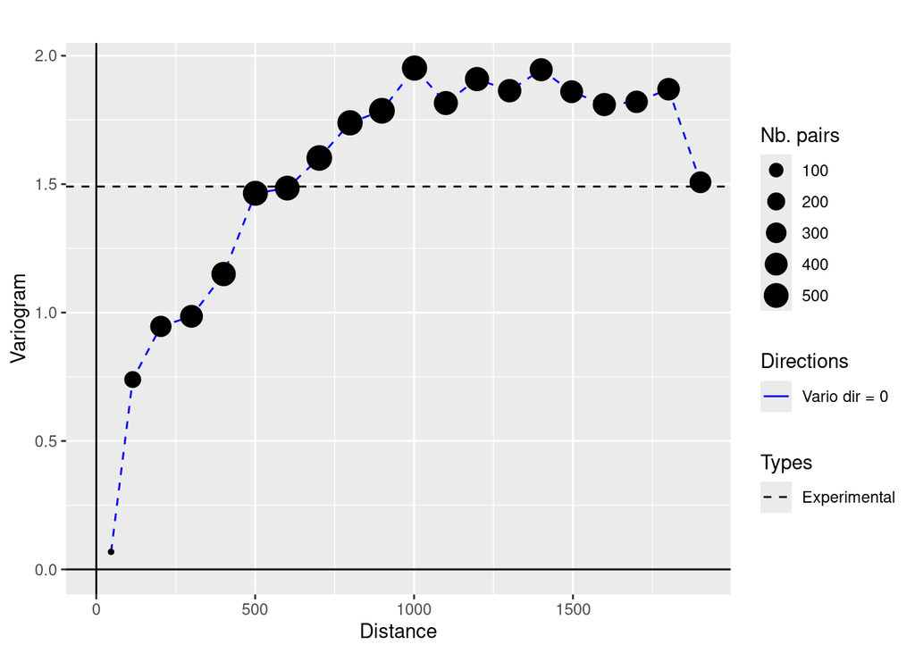

```r
plot_vario(varioexp,pairDisplay = "size")
```

We can also adapt the size of experimental variogram points in the plot so that it is proportional to the number of pairs of points used to compute the value.

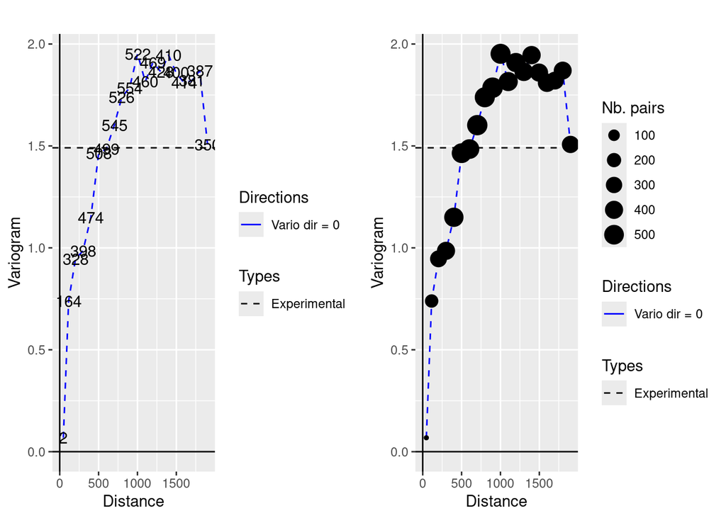

```r
p1 = plot_vario(varioexp,pairDisplay = "label")
p2 =  plot_vario(varioexp,pairDisplay = "size")
ggarrange(p1, p2, nrow = 1, ncol  = 2)
```

Trying different lags

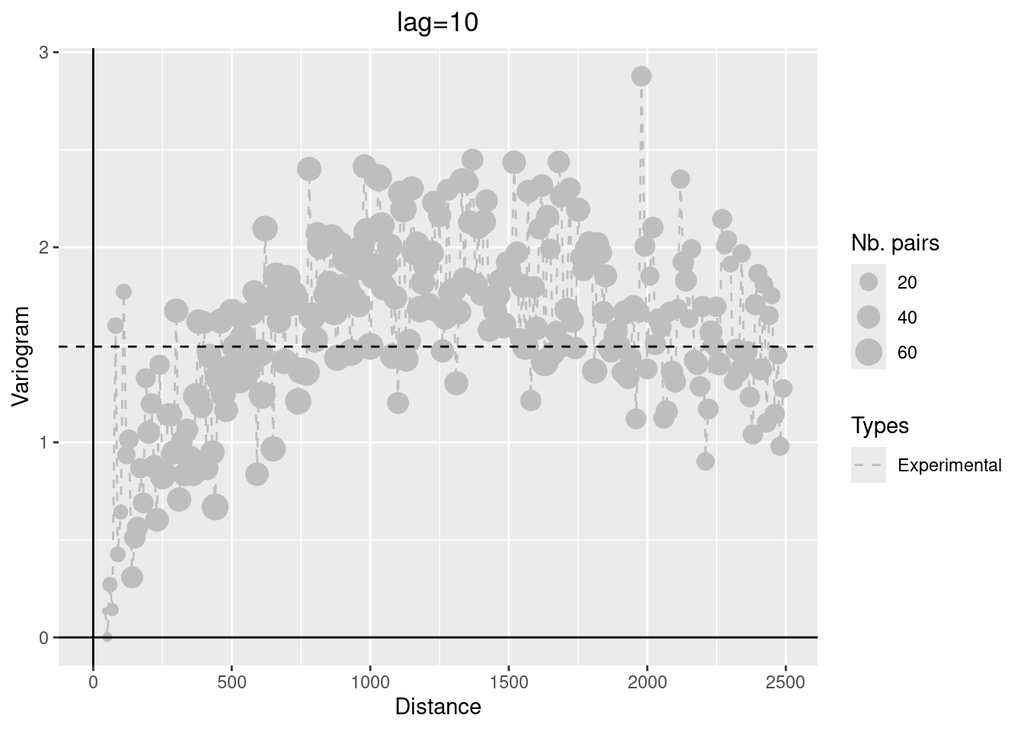

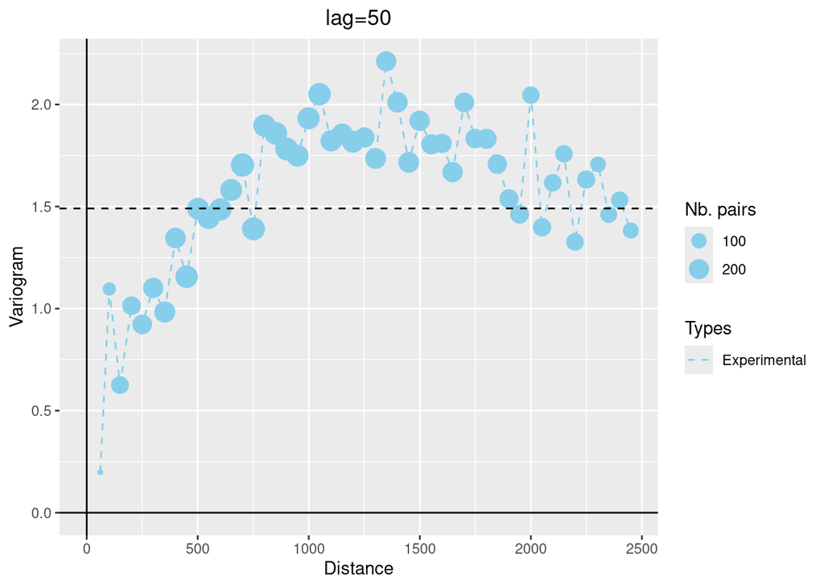

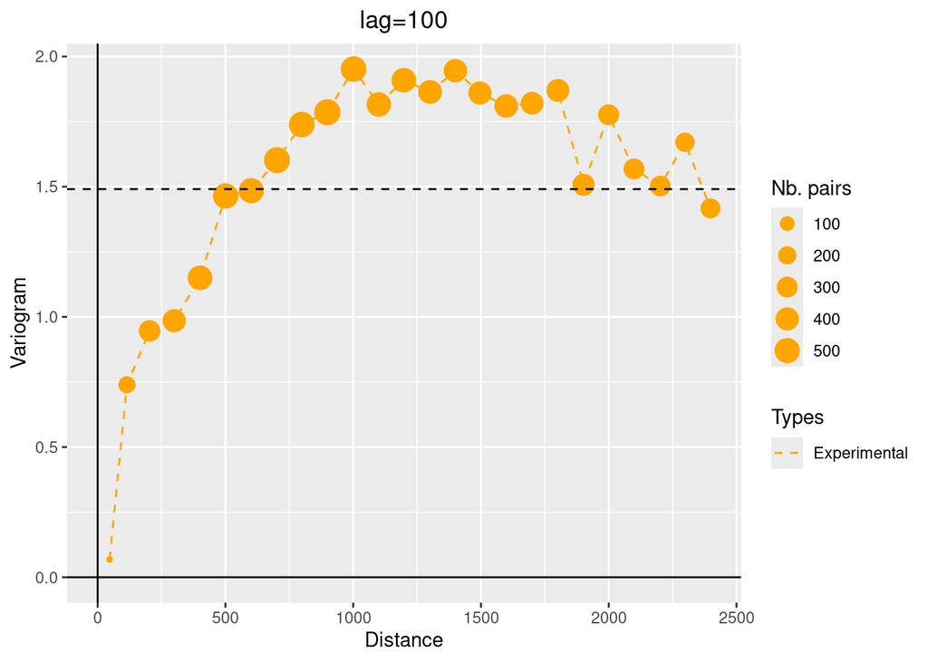

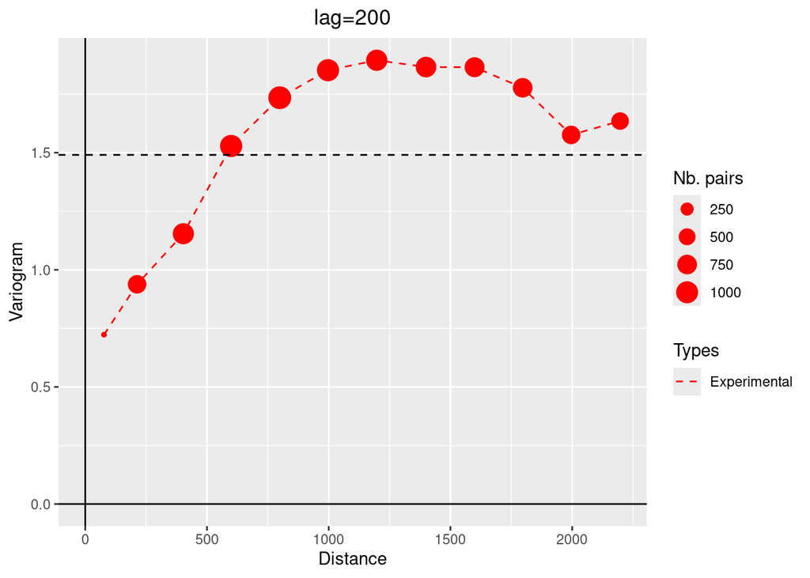

```r
col_vario = c("gray", "skyblue", "orange", "red")
lag_vario = c(10, 50, 100, 200)
for (ilag in seq(lag_vario)) {
  lag = lag_vario[ilag]

  varioexp=vario_exp(data,vname="log_cadmium",
                    nlag=2500/lag, dlag=lag, toldis = 0.5)
  plt=plot_vario(varioexp,pairDisplay = "size",color = col_vario[ilag],
                 title=paste("lag=",lag,"",sep=""))
  print(plt)

}
```

## Experimental variogram (anisotropic)

1. Compute and plot the variogram map for cadmium concentration in order to check for anisotropies.

The experimental variogram map is a map centred at the origin, which represents the value of experimental directional variogram across all directions $0^{\circ} \le \theta< 360^{\circ}$.

To compute an experimental variogram map, we use the function `db_vmap_compute` which we supply with the `Db` containing the data. The output is a `Db` containing a grid representing the variogram map values.

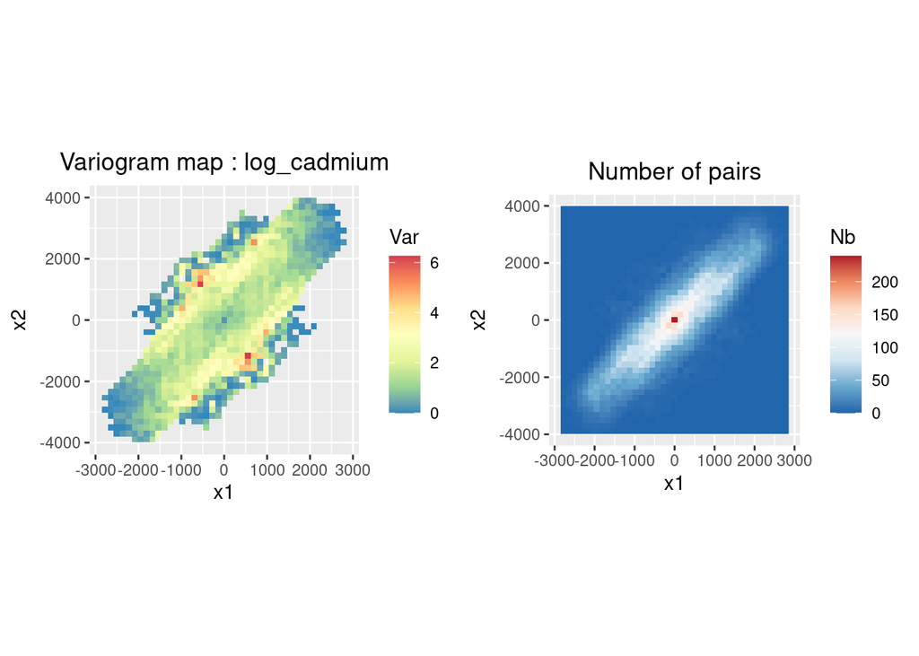

```r
grid.vmap = vario_map(data, vname="log_cadmium")

vname="log_cadmium"

vn1=grid.vmap$getNames("VMAP.*.Var")[1]
p1=dbplot_grid(grid.vmap,color= vn1,cmap="Spectral",
               legendTitle ="Var",
               title = paste0("Variogram map : ",vname))

vn2=grid.vmap$getNames("VMAP.*.Nb")[1]
p2=dbplot_grid(grid.vmap,color=vn2,cmap="RdBu",
               legendTitle ="Nb",
               title = "Number of pairs")

print(ggarrange(p1,p2,nrow=1,ncol=2, common.legend = FALSE))
```

2. Compute and plot directional variograms.

Much like their isotropic counterparts, experimental directional variograms are computed as `Vario` objects, which can be created from the `VarioParam` object (containing the parameters of the variogram) and a `Db` containing the data points.

This time, the `VarioParam` object is created using the function `VarioParam_createMultiple`. There, we specify the number $K$ of directions $\theta$ for which we wish to compute the an experimental variogram (argument `ndir`), as well as the reference angle $\theta_0$ of the first direction (argument `angref`, default = $0$) so that the directions $\theta$ = $\theta_0 + i(180/K)$ for $i=0,..., K-1$ are considered. We can also specify the number of lags $h$ for which the experimental variogram is computed (argument `npas`), and the distance between these lags (argument `npas`), as well as the tolerance $\tau$ on the lags (argument `toldis`). Then, the experimental variogram is computed just as in the isotropic case.

Note: When initializing the `VarioParam` object as described above, the angle tolerance $\eta$ is automatically set to $\eta = (90/K)$, meaning that we span the set of possible directions.

In the following example, we create an experimental variogram in the $4$ directions $\theta = 0^{\circ}, 45^{\circ}, 90^{\circ}, 135^{\circ}$.

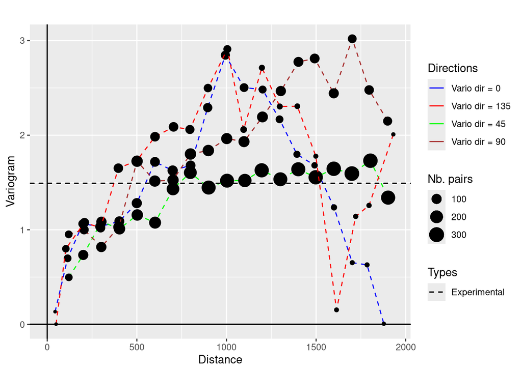

```r
vario.4dir = vario_exp(data,vname="log_cadmium",dir=c(0,45,90,135),nlag=20, dlag=100.)

plot_vario(vario.4dir,pairDisplay = "size")
```

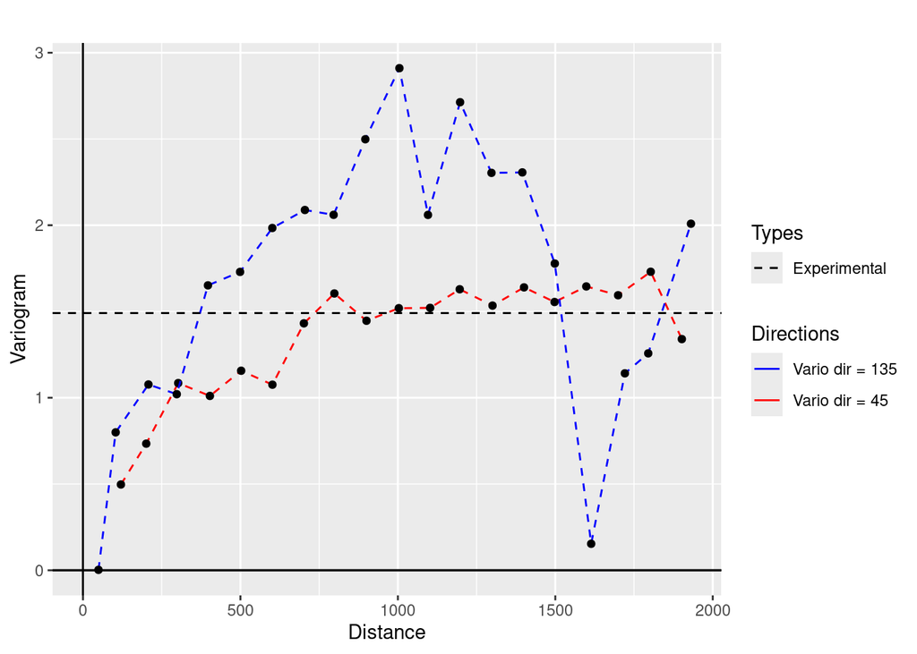

```r
vario.2dir = vario_exp(data,vname="log_cadmium",dir=c(45,135),nlag=20, dlag=100.)

plot_vario(vario.2dir)
```

```r
# ggplot() + plot.varmod(vario.2dir) + plot.decoration(title="Directionnal variogram for cadmium (45, 135)")
```

## Model adjustement

It is also possible to guide the model fitting by proposing a list of basic covariance structures from which the model is to be built. The list of available basic covariance structures is obtained by running the following command:

```r
printAllStruct()
```

```
##           Name                          Description
## 1       NUGGET                        Nugget effect
## 2  EXPONENTIAL               Exponential covariance
## 3    SPHERICAL                 Spherical covariance
## 4     GAUSSIAN                  Gaussian covariance
## 5        CUBIC                     Cubic covariance
## 6      SINCARD             Sine Cardinal covariance
## 7     BESSEL_J                  Bessel J covariance
## 8     BESSEL_K         Bessel K / Matérn covariance
## 9        GAMMA                     Gamma covariance
## 10      CAUCHY                    Cauchy covariance
## 11      STABLE                    Stable covariance
## 12      LINEAR                    Linear covariance
## 13       POWER                     Power covariance
## 14   ORDER1_GC   First Order Generalized covariance
## 15   SPLINE_GC        Spline Generalized covariance
## 16   ORDER3_GC   Third Order Generalized covariance
## 17   ORDER5_GC   Fifth Order Generalized covariance
## 18     COSINUS                    Cosine covariance
## 19    TRIANGLE                  Triangle covariance
## 20      COSEXP        Cosine Exponential covariance
## 21       REG1D               1-D Regular covariance
## 22       PENTA                Pentamodel covariance
## 23  SPLINE2_GC            Order-2 Spline covariance
## 24     STORKEY Storkey covariance in 1-D covariance
## 25   WENDLAND0            Wendland covariance (2,0)
## 26   WENDLAND1            Wendland covariance (3,1)
## 27   WENDLAND2            Wendland covariance (4,2)
## 28      MARKOV                Markovian covariances
```

1. Create and adjust a model using the method `fit` (isotropic and/or anisotropic cases) on experimental variograms and display the model characteristics.

```r
# experimental variogram
varioexp_iso = vario_exp(data,vname="log_cadmium",nlag=20, dlag=100.)

# fitting the model with the selected basic structures
struct_names=c("NUGGET","EXPONENTIAL","SPHERICAL")
model_iso=model_fit(varioexp_iso,struct=struct_names)
# display of the model
model_iso$display()
```

```
##
## Model characteristics
## =====================
## Space dimension              = 2
## Number of variable(s)        = 1
## Number of basic structure(s) = 3
## Number of drift function(s)  = 0
## Number of drift equation(s)  = 0
##
## Covariance Part
## ---------------
## Nugget Effect
## - Sill         =      0.537
## Exponential
## - Sill         =      0.000
## - Range        =   1244.998
## - Theo. Range  =    415.591
## Spherical
## - Sill         =      1.333
## - Range        =   1141.034
## Total Sill     =      1.870
## Known Mean(s)     0.000
```

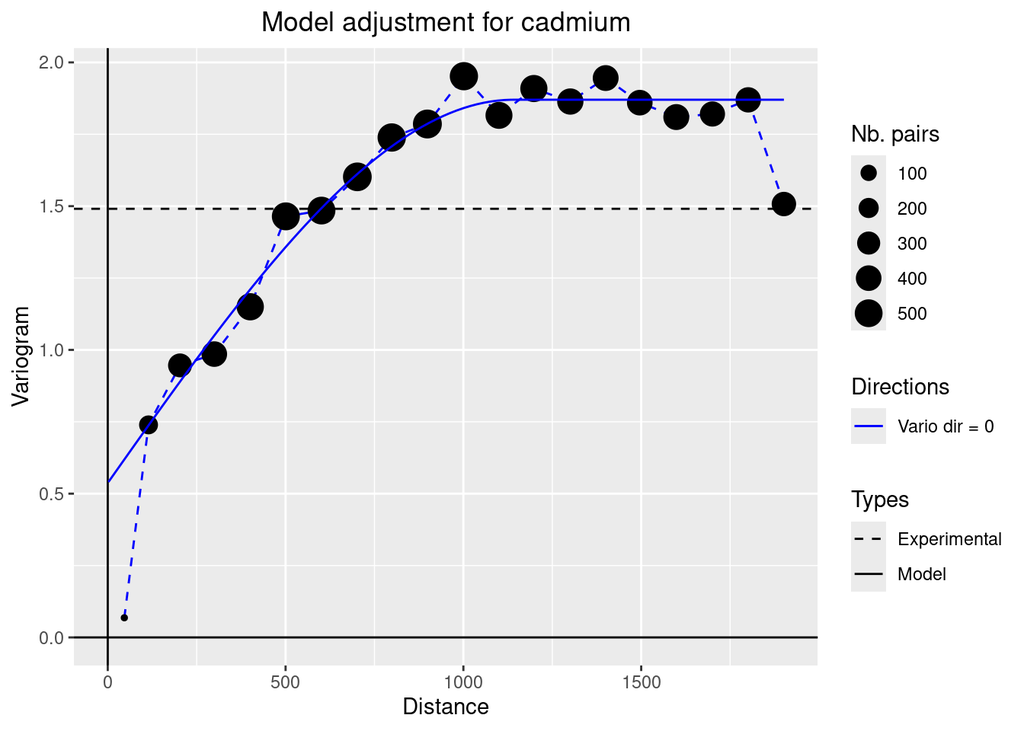

```r
# plot of the experiment variogram and the fitted model
plot_vario(varioexp_iso,model = model_iso,pairDisplay = "size",
           title="Model adjustment for cadmium")
```

```r
# experimental variogram
varioexp_aniso = vario_exp(data,vname="log_cadmium",dir=c(0,45,90,135),nlag=20, dlag=100.)

# fitting the model
model_aniso=model_fit(varioexp_aniso,struct=struct_names)
# display of the model
model_aniso$display() ## look at the anisotropic matrices
```

```
##
## Model characteristics
## =====================
## Space dimension              = 2
## Number of variable(s)        = 1
## Number of basic structure(s) = 3
## Number of drift function(s)  = 0
## Number of drift equation(s)  = 0
##
## Covariance Part
## ---------------
## Nugget Effect
## - Sill         =      0.543
## Exponential
## - Sill         =      3.354
## - Ranges       =  81421.149  5161.086
## - Theo. Ranges =  27179.050  1722.813
## - Angles       =     58.453     0.000
## - Rotation Matrix
##                [,  0]    [,  1]
##      [  0,]     0.523    -0.852
##      [  1,]     0.852     0.523
## Spherical
## - Sill         =      0.508
## - Ranges       =   3956.047   801.081
## - Angles       =    174.433     0.000
## - Rotation Matrix
##                [,  0]    [,  1]
##      [  0,]    -0.995    -0.097
##      [  1,]     0.097    -0.995
## Total Sill     =      4.405
## Known Mean(s)     0.000
```

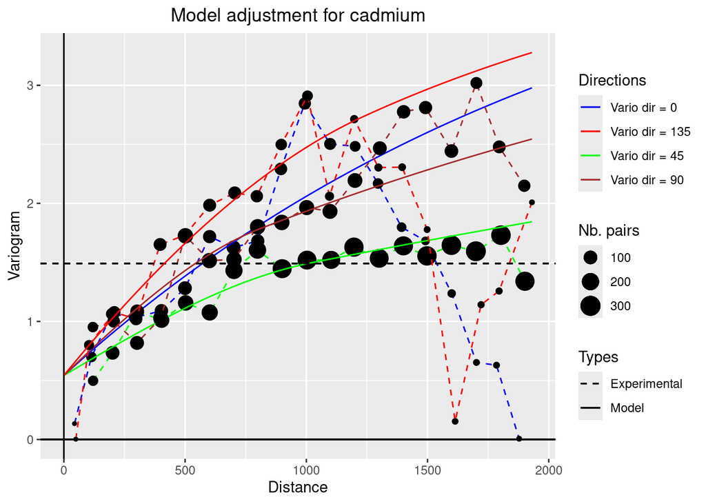

```r
# plot of the experiment variogram and the fitted model
plot_vario(varioexp_aniso,model = model_aniso,pairDisplay = "size",
           title="Model adjustment for cadmium")
```

2. Try imposing different structures or combinations of structures.

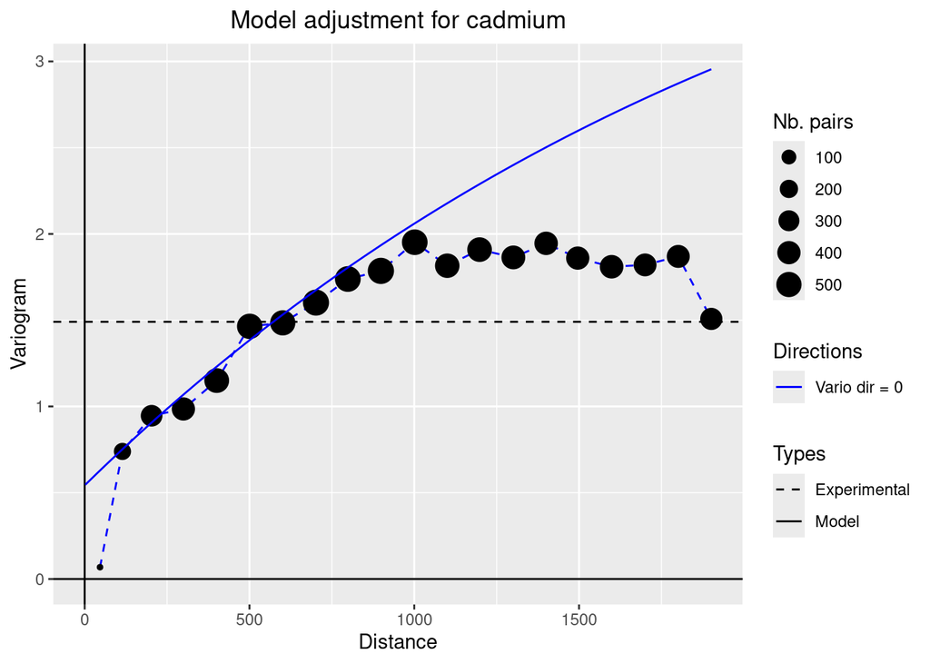

```r
struct_names = c("NUGGET","CUBIC")
# isotropic case
model_iso = model_fit(varioexp_iso,struct=struct_names)
plot_vario(varioexp_iso,model = model_aniso,pairDisplay = "size",
           title="Model adjustment for cadmium")
```

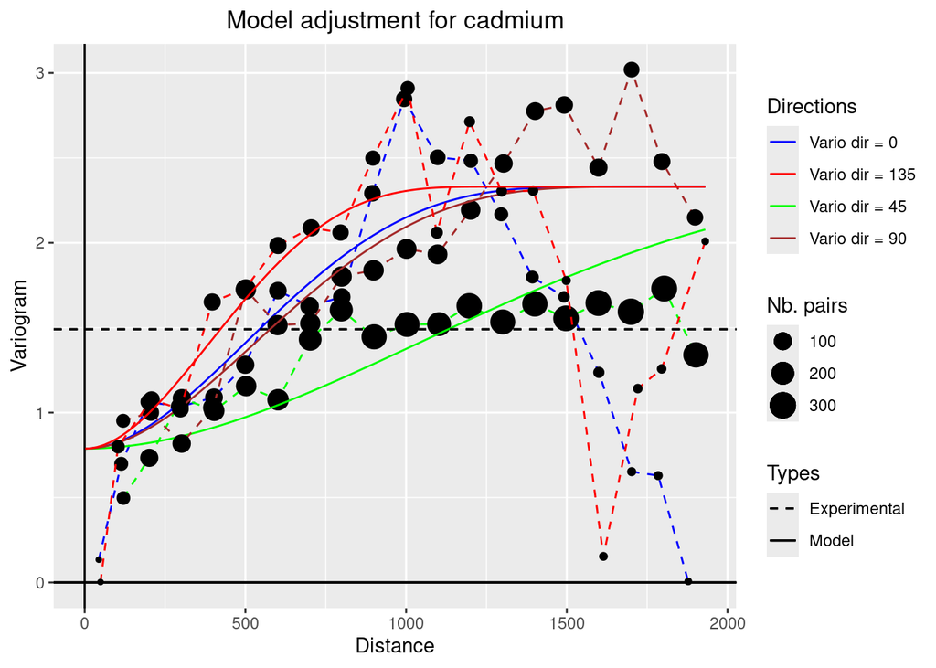

```r
# anisotropic case
model_aniso = model_fit(varioexp_aniso,struct=struct_names)
plot_vario(varioexp_aniso,model = model_aniso,pairDisplay = "size",
           title="Model adjustment for cadmium")
```

3. Compare the models adjusted on the experimental variogram and the variogram map (function `Model::fitFromVMap`).

```r
struct_names = c("NUGGET","EXPONENTIAL", "SPHERICAL")

# model fitted on the variogram map
modelVM = model_fit(grid.vmap,struct=struct_names)
modelVM$display()
```

```
##
## Model characteristics
## =====================
## Space dimension              = 2
## Number of variable(s)        = 1
## Number of basic structure(s) = 3
## Number of drift function(s)  = 0
## Number of drift equation(s)  = 0
##
## Covariance Part
## ---------------
## Nugget Effect
## - Sill         =      0.438
## Exponential
## - Sill         =      1.128
## - Ranges       =    877.990  1023.457
## - Theo. Ranges =    293.080   341.638
## - Angles       =    147.695     0.000
## - Rotation Matrix
##                [,  0]    [,  1]
##      [  0,]     0.845     0.534
##      [  1,]    -0.534     0.845
## Spherical
## - Sill         =      0.000
## - Ranges       =   4180.236  2195.310
## - Angles       =    131.836     0.000
## - Rotation Matrix
##                [,  0]    [,  1]
##      [  0,]     0.667     0.745
##      [  1,]    -0.745     0.667
## Total Sill     =      1.566
## Known Mean(s)     0.000
```

```r
# model fitted on the experimental variogram (4 directions)
modelexp = model_fit(varioexp_aniso,struct=struct_names)
modelexp$display()
```

```
##
## Model characteristics
## =====================
## Space dimension              = 2
## Number of variable(s)        = 1
## Number of basic structure(s) = 3
## Number of drift function(s)  = 0
## Number of drift equation(s)  = 0
##
## Covariance Part
## ---------------
## Nugget Effect
## - Sill         =      0.543
## Exponential
## - Sill         =      3.354
## - Ranges       =  81421.149  5161.086
## - Theo. Ranges =  27179.050  1722.813
## - Angles       =     58.453     0.000
## - Rotation Matrix
##                [,  0]    [,  1]
##      [  0,]     0.523    -0.852
##      [  1,]     0.852     0.523
## Spherical
## - Sill         =      0.508
## - Ranges       =   3956.047   801.081
## - Angles       =    174.433     0.000
## - Rotation Matrix
##                [,  0]    [,  1]
##      [  0,]    -0.995    -0.097
##      [  1,]     0.097    -0.995
## Total Sill     =      4.405
## Known Mean(s)     0.000
```

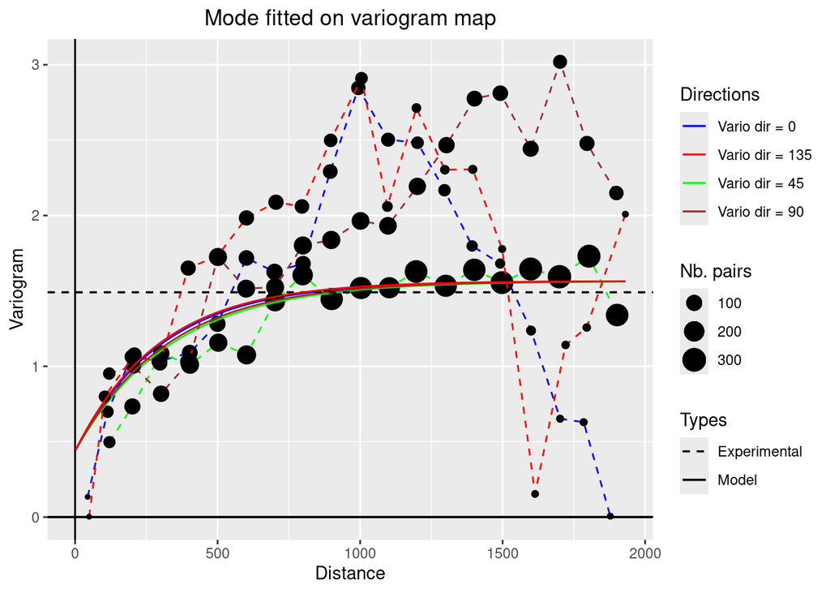

```r
# comparison with the model adjusted on the variogram (plot both models)
plot_vario(varioexp_aniso,model = modelVM, pairDisplay = "size",
           title="Mode fitted on variogram map")
```

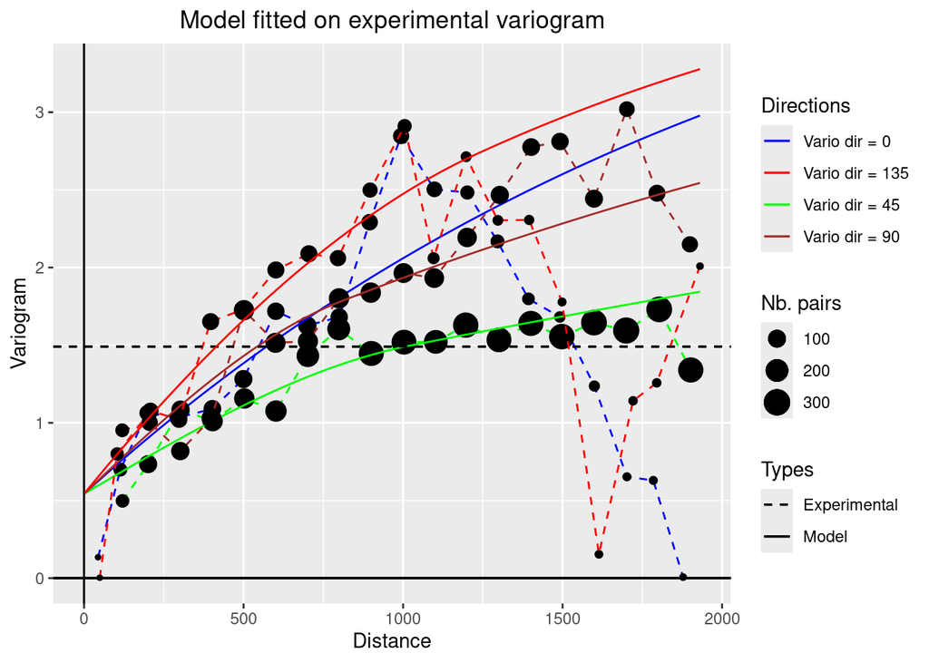

```r
plot_vario(varioexp_aniso,model = modelexp, pairDisplay = "size",
           title="Model fitted on experimental variogram")
```

## Multivariate variograms

1. Compute the variograms and cross variograms for all metals, with and without anisotropy.

```r
# Variable names
variable_names=paste0("log_", c("cadmium","copper","lead","zinc"))

# omni-directional variograms and cross variograms
vario_iso4var = vario_exp(data,vname=variable_names,nlag=20, dlag=100.)
dev.new() # Open new window
plot_vario(vario_iso4var)

# directional variograms and cross variograms
vario_aniso4var = vario_exp(data,vname=variable_names,dir=c(0,45,90,135),nlag=20, dlag=100.)
dev.new() # Open new window
plot_vario(vario_aniso4var)
```

[output not shown]

2. Adjust a model (try several options) using the function `model_fit` (isotropic and/or anisotropic cases) on experimental variograms and display the model characteristics.

```r
# selection of possible structures
struct_names = c("NUGGET","EXPONENTIAL")

# isotropic case
model_iso4var=model_fit(vario_iso4var,struct=struct_names)

# Display and plot
model_iso4var$display()
```

```
##
## Model characteristics
## =====================
## Space dimension              = 2
## Number of variable(s)        = 4
## Number of basic structure(s) = 2
## Number of drift function(s)  = 0
## Number of drift equation(s)  = 0
##
## Covariance Part
## ---------------
## Nugget Effect
## - Sill matrix:
##                [,  0]    [,  1]    [,  2]    [,  3]
##      [  0,]     0.260     0.071    -0.014     0.013
##      [  1,]     0.071     0.052    -0.001     0.010
##      [  2,]    -0.014    -0.001     0.003    -0.003
##      [  3,]     0.013     0.010    -0.003     0.005
## Exponential
## - Sill matrix:
##                [,  0]    [,  1]    [,  2]    [,  3]
##      [  0,]     1.648     0.580     0.889     0.988
##      [  1,]     0.580     0.258     0.369     0.411
##      [  2,]     0.889     0.369     0.574     0.607
##      [  3,]     0.988     0.411     0.607     0.668
## - Range        =   1231.097
## - Theo. Range  =    410.950
## Total Sill
##                [,  0]    [,  1]    [,  2]    [,  3]
##      [  0,]     1.908     0.651     0.875     1.001
##      [  1,]     0.651     0.310     0.368     0.421
##      [  2,]     0.875     0.368     0.578     0.604
##      [  3,]     1.001     0.421     0.604     0.672
##
## Known Mean(s)     0.000     0.000     0.000     0.000
```

```r
dev.new()
plot_vario(vario_iso4var, model_iso4var)


# selection of the variables
ivar = 1
jvar = 3


p1 = plot_vario(vario_iso4var, model_iso4var, ivar = ivar, jvar = ivar,
                title = paste0(variable_names[1+ivar], "-", variable_names[1+ivar]))
p2 = plot_vario(vario_iso4var, model_iso4var, ivar = ivar, jvar = jvar,
                title = paste0(variable_names[1+ivar], "-", variable_names[1+jvar]))
p3 = plot_vario(vario_iso4var, model_iso4var, ivar = jvar, jvar = jvar,
                title = paste0(variable_names[1+jvar], "-", variable_names[1+jvar]))

dev.new()
ggarrange(p1, p2, p3, ncol = 3, nrow = 1,legend = "bottom",common.legend = TRUE)
```

[output not shown]

```r
# selection of possible structures
struct_names = c("NUGGET","EXPONENTIAL")

# anisotropic case
model_aniso4var=model_fit(vario_aniso4var,struct=struct_names)

model_aniso4var$display()
```

```
##
## Model characteristics
## =====================
## Space dimension              = 2
## Number of variable(s)        = 4
## Number of basic structure(s) = 2
## Number of drift function(s)  = 0
## Number of drift equation(s)  = 0
##
## Covariance Part
## ---------------
## Nugget Effect
## - Sill matrix:
##                [,  0]    [,  1]    [,  2]    [,  3]
##      [  0,]     0.516     0.120     0.073     0.111
##      [  1,]     0.120     0.071     0.026     0.042
##      [  2,]     0.073     0.026     0.047     0.038
##      [  3,]     0.111     0.042     0.038     0.050
## Exponential
## - Sill matrix:
##                [,  0]    [,  1]    [,  2]    [,  3]
##      [  0,]     2.336     0.964     1.446     1.600
##      [  1,]     0.964     0.441     0.638     0.707
##      [  2,]     1.446     0.638     0.974     1.048
##      [  3,]     1.600     0.707     1.048     1.151
## - Ranges       =   2021.422  8167.377
## - Theo. Ranges =    674.767  2726.338
## - Angles       =    140.632     0.000
## - Rotation Matrix
##                [,  0]    [,  1]
##      [  0,]     0.773     0.634
##      [  1,]    -0.634     0.773
## Total Sill
##                [,  0]    [,  1]    [,  2]    [,  3]
##      [  0,]     2.851     1.084     1.519     1.711
##      [  1,]     1.084     0.512     0.665     0.749
##      [  2,]     1.519     0.665     1.020     1.086
##      [  3,]     1.711     0.749     1.086     1.202
##
## Known Mean(s)     0.000     0.000     0.000     0.000
```

```r
dev.new()
plot_vario(vario_aniso4var, model_aniso4var)

# selection of the variables
ivar = 1
jvar = 3

p1 = plot_vario(vario_aniso4var, model_aniso4var, ivar = ivar, jvar = ivar,
                title = paste0(variable_names[1+ivar], "-", variable_names[1+ivar]))
p2 = plot_vario(vario_aniso4var, model_aniso4var, ivar = ivar, jvar = jvar,
                title = paste0(variable_names[1+ivar], "-", variable_names[1+jvar]))
p3 = plot_vario(vario_aniso4var, model_aniso4var, ivar = jvar, jvar = jvar,
                title = paste0(variable_names[1+jvar], "-", variable_names[1+jvar]))

dev.new()
ggarrange(p1, p2, p3, ncol = 3, nrow = 1,legend = "bottom",common.legend = TRUE)
```

[output not shown]